# Clustering

```python
import pandas as pd
import numpy as np
import os
from NuestrasFunciones import *
pd.set_option("display.max_rows", None, "display.max_columns", None)
# Preprocesado y modelado
# ==============================================================================
from sklearn.cluster import KMeans
from sklearn.preprocessing import scale
from sklearn.metrics import silhouette_score
from sklearn.decomposition import PCA
from sklearn.cluster import KMeans
from sklearn.preprocessing import scale
from sklearn.metrics import silhouette_score
from sklearn.preprocessing import StandardScaler
#from factor_analyzer.factor_analyzer import calculate_bartlett_sphericit

# Configuración warnings
# ==============================================================================
import warnings
warnings.filterwarnings('ignore')
```

### PRELIMINARES

```python
companies=pd.read_csv('companies_procesado.csv')
companies.head()
```

|  | company | city | country | employees | employee type | revenues | revenue type | company type | website | sector | industry | foundation year | LinkedIn link | stack | ESG score | environmental score (ESG) | social score (ESG) | governance score (ESG) | talking points |
| --- | --- | --- | --- | --- | --- | --- | --- | --- | --- | --- | --- | --- | --- | --- | --- | --- | --- | --- | --- |
| 0 | Ecopetrol | Bogotá | Colombia | 130.0 | actual | 60947029 | actual | public | https://www.ecopetrol.com.co | Energy | Oil, Gas & Consumable Fuels | 1998.5 | https://www.linkedin.com/company/ecopetroloficial | google analytics | 77.445044 | 16.259518 | 26.654757 | 24.459248 | Ecopetrol \| Energía y SosTECnibilidad®, Bienve... |
| 1 | SENA | Bogotá | Colombia | 406.0 | estimate | 60947029 | estimate | private | https://sena.edu.co | Consumer Discretionary | Diversified Consumer Services | 1998.5 | https://www.linkedin.com/company/sena | google analytics | 84.385950 | 28.002964 | 26.974150 | 24.499004 | The URL you requested has been blocked, Cuenta... |
| 2 | Airfrance | Colombia | Colombia | 406.0 | estimate | 60947029 | estimate | private | https://wwws.airfrance.com.co | Industrials | Passenger Airlines | 2005.0 | https://www.linkedin.com/company/air-france | google analytics | 77.445044 | 29.871284 | 28.187340 | 23.887934 | Avión Al Mejor Precio - Vuelos Air France Colo... |
| 3 | Grupo SURA | Medellín | Colombia | 130.0 | actual | 60947029 | actual | private | https://www.gruposura.com | Financials | Insurance | 1998.5 | https://www.linkedin.com/company/grupo-sura | google analytics | 79.558290 | 40.969627 | 25.882753 | 20.825842 | Grupo SURAGestor de inversiones con foco en se... |
| 4 | Uniandes | Bogotá | Colombia | 406.0 | estimate | 60947029 | estimate | private | https://uniandes.edu.co | Consumer Discretionary | Diversified Consumer Services | 1998.5 | https://www.linkedin.com/company/universidad-d... | google analytics | 84.385950 | 28.002964 | 26.974150 | 24.499004 | Home \| University of Los Andes, The University... |

```python
companies.info()
```

```
<class 'pandas.core.frame.DataFrame'>
RangeIndex: 86955 entries, 0 to 86954
Data columns (total 19 columns):
 #   Column                     Non-Null Count  Dtype
---  ------                     --------------  -----
 0   company                    86955 non-null  object
 1   city                       86955 non-null  object
 2   country                    86955 non-null  object
 3   employees                  86955 non-null  float64
 4   employee type              86955 non-null  object
 5   revenues                   86955 non-null  int64
 6   revenue type               86955 non-null  object
 7   company type               86955 non-null  object
 8   website                    86955 non-null  object
 9   sector                     86955 non-null  object
 10  industry                   86955 non-null  object
 11  foundation year            86955 non-null  float64
 12  LinkedIn link              86955 non-null  object
 13  stack                      86955 non-null  object
 14  ESG score                  86955 non-null  float64
 15  environmental score (ESG)  86955 non-null  float64
 16  social score (ESG)         86955 non-null  float64
 17  governance score (ESG)     86955 non-null  float64
 18  talking points             86955 non-null  object
dtypes: float64(6), int64(1), object(12)
memory usage: 12.6+ MB
```

```python
companies.nunique()
```

```
company                      86186
city                          2318
country                          2
employees                      405
employee type                    2
revenues                     44165
revenue type                     2
company type                     2
website                      86955
sector                          11
industry                        58
foundation year                 14
LinkedIn link                61725
stack                          133
ESG score                      110
environmental score (ESG)      104
social score (ESG)              85
governance score (ESG)          89
talking points               81067
dtype: int64
```

```python
# Lista de columnas con menos de 10 valores distintos. Potenciales factores!
to_factor = list(companies.loc[:,companies.nunique() < 10]);

# Podemos cambiar el tipo de todas ellas a factor de una vez
companies[to_factor] = companies[to_factor].astype('category')
```

```python
companies.info()
```

```
<class 'pandas.core.frame.DataFrame'>
RangeIndex: 86955 entries, 0 to 86954
Data columns (total 19 columns):
 #   Column                     Non-Null Count  Dtype
---  ------                     --------------  -----
 0   company                    86955 non-null  object
 1   city                       86955 non-null  object
 2   country                    86955 non-null  category
 3   employees                  86955 non-null  float64
 4   employee type              86955 non-null  category
 5   revenues                   86955 non-null  int64
 6   revenue type               86955 non-null  category
 7   company type               86955 non-null  category
 8   website                    86955 non-null  object
 9   sector                     86955 non-null  object
 10  industry                   86955 non-null  object
 11  foundation year            86955 non-null  float64
 12  LinkedIn link              86955 non-null  object
 13  stack                      86955 non-null  object
 14  ESG score                  86955 non-null  float64
 15  environmental score (ESG)  86955 non-null  float64
 16  social score (ESG)         86955 non-null  float64
 17  governance score (ESG)     86955 non-null  float64
 18  talking points             86955 non-null  object
dtypes: category(4), float64(6), int64(1), object(8)
memory usage: 10.3+ MB
```

Con estos datos podemos recategorizar las variables, sector con 11 variables y foundation year con 14

```python
companies['sector'].value_counts().to_frame()
```

| sector | count |
| --- | --- |
| Industrials | 44156 |
| Communication Services | 12872 |
| Consumer Discretionary | 10143 |
| Information Technology | 5209 |
| Financials | 4074 |
| Health Care | 3826 |
| Consumer Staples | 3340 |
| Materials | 1187 |
| Utilities | 1019 |
| Real Estate | 873 |
| Energy | 256 |

```python
def recategorize_sector(row):
    if row == 'Industrials':
        return 'Industrials'
    elif row == 'Communication Services':
        return 'Communication Services'
    elif row == 'Consumer Discretionary':
        return 'Consumer Discretionary'
    elif row == 'Information Technology':
        return 'Information Technology'
    elif row in ['Financials', 'Real Estate']:
        return 'Financials & Real Estate'
    elif row in ['Health Care', 'Consumer Staples']:
        return 'Health & Consumer Staples'
    elif row in ['Energy', 'Utilities', 'Materials']:
        return 'Energy, Utilities & Materials'
    else:
        return 'Other'  # Para casos no esperados

companies['sector'] = companies['sector'].apply(recategorize_sector)
```

```python
companies['sector'].value_counts().to_frame()
```

| sector | count |
| --- | --- |
| Industrials | 44156 |
| Communication Services | 12872 |
| Consumer Discretionary | 10143 |
| Health & Consumer Staples | 7166 |
| Information Technology | 5209 |
| Financials & Real Estate | 4947 |
| Energy, Utilities & Materials | 2462 |

Agrupaciones Propuestas:

- Financials & Real Estate: Incluye Financials (4,074) y Real Estate (873).
- Health & Consumer Staples: Incluye Health Care (3,826) y Consumer Staples (3,340).
- Energy, Utilities & Materials: Incluye Energy (256), Utilities (1,019) y Materials (1,187).
- Verificación: La suma de las nuevas categorías debe ser 86,955.

```python
companies.nunique()
```

```
company                      86186
city                          2318
country                          2
employees                      405
employee type                    2
revenues                     44165
revenue type                     2
company type                     2
website                      86955
sector                           7
industry                        58
foundation year                 14
LinkedIn link                61725
stack                          133
ESG score                      110
environmental score (ESG)      104
social score (ESG)              85
governance score (ESG)          89
talking points               81067
dtype: int64
```

```python
# Lista de columnas con menos de 10 valores distintos. Potenciales factores!
to_factor = list(companies.loc[:,companies.nunique() < 10]);

# Podemos cambiar el tipo de todas ellas a factor de una vez
companies[to_factor] = companies[to_factor].astype('category')
```

```python
companies.info()
```

```
<class 'pandas.core.frame.DataFrame'>
RangeIndex: 86955 entries, 0 to 86954
Data columns (total 19 columns):
 #   Column                     Non-Null Count  Dtype
---  ------                     --------------  -----
 0   company                    86955 non-null  object
 1   city                       86955 non-null  object
 2   country                    86955 non-null  category
 3   employees                  86955 non-null  float64
 4   employee type              86955 non-null  category
 5   revenues                   86955 non-null  int64
 6   revenue type               86955 non-null  category
 7   company type               86955 non-null  category
 8   website                    86955 non-null  object
 9   sector                     86955 non-null  category
 10  industry                   86955 non-null  object
 11  foundation year            86955 non-null  float64
 12  LinkedIn link              86955 non-null  object
 13  stack                      86955 non-null  object
 14  ESG score                  86955 non-null  float64
 15  environmental score (ESG)  86955 non-null  float64
 16  social score (ESG)         86955 non-null  float64
 17  governance score (ESG)     86955 non-null  float64
 18  talking points             86955 non-null  object
dtypes: category(5), float64(6), int64(1), object(7)
memory usage: 9.7+ MB
```

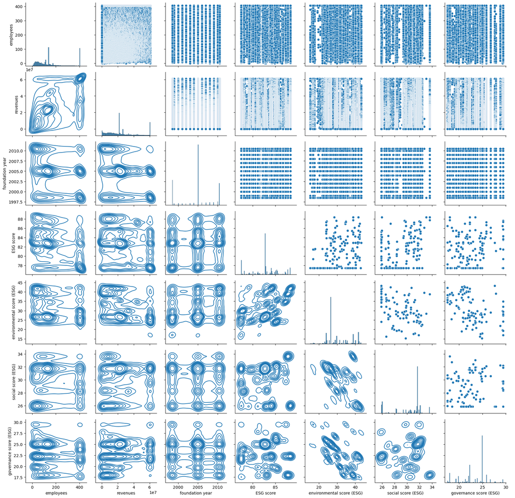

```python
import seaborn as sns

grafico = sns.PairGrid(companies.iloc[:])
grafico.map_diag( sns.histplot) #representar en diagonal este tipo de diagrama (histograma)
grafico.map_lower( sns.kdeplot ) #representar arriba de la diagonal este tipo de diagrama (kernel density estimate, estima la probabilidad de la función de densidad de variables continuas)
grafico.map_upper(sns.scatterplot ) #representar arriba de la diagonal este tipo de diagrama (dispersión)
grafico.add_legend()
```

Realizando una verificacion a la matriz de dispersión mostrando las relaciones entre las variables numéricas del dataset: employees, revenues, foundation year, ESG score, environmental score (ESG), social score (ESG) y governance score (ESG):

- Employees vs. Revenues: Muestra una tendencia positiva débil, con algunos puntos dispersos. Las empresas con más empleados tienden a tener mayores ingresos, pero la uniformidad en "revenues" dificulta la identificación clara de clústeres. Podría ser útil log-transformar estas variables.
- Visual: Nube de puntos con tendencia positiva moderada (a más empleados, más ingresos), pero con dispersión creciente (heteroscedasticidad: varianza aumenta con valores altos). Forma ligeramente curvilínea en bajos valores.
- -ESG Score: Distribución ligeramente sesgada a la izquierda, con valores concentrados entre 77 y 85. Sugiere un grupo principal de empresas con buen desempeño ESG y posibles subgrupos con puntajes más bajos.
- -Variables Candidatas para Clustering

Basado en las tendencias observadas, las variables numéricas más prometedoras para un análisis de clustering son:

- -Employees: Por su bimodalidad, permite identificar grupos de tamaño de empresa.
- Environmental Score (ESG), Social Score (ESG), Governance Score (ESG): Su variabilidad y distribución sesgada ofrecen potencial para clústeres basados en desempeño ESG (e.g., alto vs. bajo impacto ambiental, social, o gobernanza).
- - ESG Score: Como agregado, puede servir para un clúster general de sostenibilidad, aunque su distribución es menos marcada.

### Test hopkins

Realizaremos la tecnica estadistica para corroborar si el conjunto de datos tiene una significativa formar cluster, o por el contrario los datos estan distribuidos aleatoriamente en el espacio de caracteristicas.

```python
from sklearn.neighbors import NearestNeighbors
from random import sample
from numpy.random import uniform
import numpy as np

def hopkins(X):
    d = X.shape[1]
    n = len(X)
    m = int(0.1 * n)
    nbrs = NearestNeighbors(n_neighbors=1).fit(X)

    rand_X = uniform(X.min(axis=0), X.max(axis=0), (m, d))
    ujd = []
    wjd = []
    for j in range(m):
        u_dist, _ = nbrs.kneighbors(rand_X[j].reshape(1, -1), 2, return_distance=True)
        ujd.append(u_dist[0][1])
        w_dist, _ = nbrs.kneighbors(X[np.random.choice(n, 1, replace=False)].reshape(1, -1), 2, return_distance=True)
        wjd.append(w_dist[0][1])

    H = sum(ujd) / (sum(ujd) + sum(wjd))
    return H

# Suponiendo que desee comprobar la tendencia de agrupación de las columnas numéricas
numerical_cols = companies.select_dtypes(include=np.number).columns
data_for_hopkins = companies[numerical_cols].values

hopkins_statistic = hopkins(data_for_hopkins)
print(f"Hopkins statistic: {hopkins_statistic}")

if hopkins_statistic > 0.5:
    print("Los datos tienen tendencia a cluester")
else:
    print("Los datos no tienen tendencia a cluester")
```

```
Hopkins statistic: 0.8804608619587033
Los datos tienen tendencia a cluester
```

### INTERPRETACIÓN

- Dado que el valor es mayor a 0.5 (umbral común para detectar tendencia a clústeres), esto confirma que las variables numéricas analizadas (employees, revenues, foundation year, ESG score, environmental score (ESG), social score (ESG), governance score (ESG)) presentan patrones que pueden ser aprovechados para un análisis de clustering.

```python
# Seleccionar columnas numéricas que puedan ser relevantes para la agrupación
numerical_features = ['employees', 'revenues', 'foundation year', 'ESG score', 'environmental score (ESG)', 'social score (ESG)', 'governance score (ESG)']

# Select categorical columns that could be relevant and can be encoded
categorical_features = ['country', 'employee type', 'revenue type', 'company type', 'sector', 'industry']

# Combine the selected features into a single list
selected_features = numerical_features + categorical_features

print("Selected features for clustering:")
print(selected_features)
```

```
Selected features for clustering:
['employees', 'revenues', 'foundation year', 'ESG score', 'environmental score (ESG)', 'social score (ESG)', 'governance score (ESG)', 'country', 'employee type', 'revenue type', 'company type', 'sector', 'industry']
```

## Clustering Jerárquico

- Los métodos de clustering jerárquico servirán para hacerse una idea de la dinámica de agrupación de los datos y proponer, en base al dendograma, un número de grupos tentativos que presenten características comunes.

```python
grupos = companies.groupby('employees').agg({'revenues': 'sum', 'foundation year': 'mean',
                                   'ESG score': 'mean', 'environmental score (ESG)': 'mean',
                                   'social score (ESG)': 'mean', 'governance score (ESG)': 'mean'}, )


grupos
```

| employees | revenues | foundation year | ESG score | environmental score (ESG) | social score (ESG) | governance score (ESG) |
| --- | --- | --- | --- | --- | --- | --- |
| 1.0 | 172083064 | 2006.714286 | 83.374817 | 32.476852 | 29.620475 | 23.920705 |
| 3.0 | 114464773 | 2004.357143 | 83.288734 | 33.178092 | 28.396652 | 21.615097 |
| 4.0 | 158214745 | 2007.821429 | 82.119766 | 37.068438 | 28.286380 | 22.995420 |
| 5.0 | 226213436 | 2005.763158 | 82.389892 | 36.602817 | 28.554244 | 23.409349 |
| 6.0 | 886867980 | 2006.770000 | 83.793406 | 37.338127 | 28.121886 | 23.341134 |
| 7.0 | 651449620 | 2006.686441 | 83.509220 | 35.537669 | 29.009112 | 23.714651 |
| 8.0 | 784506091 | 2006.772152 | 82.581797 | 35.331441 | 28.807426 | 23.426326 |
| 9.0 | 1471139560 | 2006.892857 | 83.602605 | 36.142977 | 28.665790 | 23.343156 |
| 10.0 | 1931285981 | 2006.522556 | 83.352474 | 35.082036 | 28.867882 | 23.079027 |
| 11.0 | 1756604951 | 2006.644295 | 83.371991 | 36.010206 | 28.638817 | 23.283972 |
| 12.0 | 1904595224 | 2006.643713 | 83.557287 | 35.819748 | 28.568365 | 23.195711 |
| 13.0 | 2129314983 | 2006.459239 | 83.352884 | 35.076318 | 28.943099 | 23.819684 |
| 14.0 | 2705875938 | 2007.044304 | 83.615050 | 34.921092 | 29.055666 | 23.442338 |
| 15.0 | 3317225318 | 2006.584532 | 83.874513 | 35.385469 | 28.769386 | 23.975513 |
| 16.0 | 3912037130 | 2007.036789 | 83.585518 | 33.789508 | 29.466669 | 23.445895 |
| 17.0 | 3581126572 | 2006.556818 | 83.595095 | 34.037360 | 29.342820 | 23.617208 |
| 18.0 | 3624510451 | 2006.966049 | 83.456001 | 34.812203 | 29.114233 | 23.160792 |
| 19.0 | 4016352064 | 2006.831006 | 83.670496 | 33.640244 | 29.779690 | 22.964076 |
| 20.0 | 4271571870 | 2006.964115 | 83.512511 | 33.293313 | 29.463802 | 23.677360 |
| 21.0 | 3423150485 | 2006.757353 | 83.714750 | 34.607460 | 29.459321 | 22.845321 |
| 22.0 | 4928262203 | 2006.671591 | 83.417391 | 33.202753 | 29.603653 | 23.496016 |
| 23.0 | 4803728770 | 2006.722101 | 83.647499 | 32.834150 | 29.705506 | 23.685219 |
| 24.0 | 5360239538 | 2006.566225 | 83.704426 | 34.058132 | 29.445491 | 22.980886 |
| 25.0 | 5637332628 | 2007.050000 | 83.716313 | 33.358695 | 29.533444 | 23.513678 |
| 26.0 | 5775371077 | 2006.480962 | 83.711116 | 33.193445 | 29.526928 | 23.396382 |
| 27.0 | 5860949394 | 2006.972803 | 83.828200 | 33.649581 | 29.390035 | 23.160281 |
| 28.0 | 6021138579 | 2006.657197 | 83.768030 | 33.628182 | 29.404189 | 23.380280 |
| 29.0 | 6772295406 | 2006.608083 | 83.873718 | 33.375893 | 29.688817 | 23.270135 |
| 30.0 | 5021071999 | 2006.088164 | 83.816124 | 33.915895 | 29.263212 | 23.181865 |
| 31.0 | 6181318949 | 2006.690154 | 83.633638 | 33.339531 | 29.324509 | 23.497769 |

[output cut: 375 more lines]